# Workshop on Julia - Introduction to Julia for Statistics

## ANZ Statistics Conference, University of Canterbury, November 2015

## Arindam Basu MB BS MPH PhD

## School of Health Sciences,

## Email: arindam.basu@canterbury.ac.nz

## Sessions

Hello and welcome to the Julia workshop. The purpose of this workshop and indeed this document is to introduce Julia, a programming language that is flexible, easy to use and quite intuitive.

## Session Timings

- 9-10:00 AM - Session 1: About, Download, Installation
- 10-10:30 AM - Hands on Installation with different options
- 10:30 AM - Morning Tea
- 10:40-12:00 - Session 2: Introduction to Julia Language
- 12:00-1:00 PM - Session 3: Data Analysis and Graphics using Julia
- 1:00 PM - Questions and answers, we break for lunch

## Session 1: About Julia, Download, Installation

## Getting started

[figure not shown]

## What is Julia?

From the Julia website,

"Julia is a high-level, high-performance dynamic programming language for technical computing, with syntax that is familiar to users of other technical computing environments. It provides a sophisticated compiler, distributed parallel execution, numerical accuracy, and an extensive mathematical function library. Julia’s Base library, largely written in Julia itself, also integrates mature, best-of-breed open source C and Fortran libraries for linear algebra, random number generation, signal processing, and string processing. In addition, the Julia developer community is contributing a number of external packages through Julia’s built-in package manager at a rapid pace. IJulia, a collaboration between the IPython and Julia communities, provides a powerful browser-based graphical notebook interface to Julia."

## Why Might We be Interested in Julia

- Good for custom work and writing your own programme
- Useful Built-in functions and Packages
- Very extensible
- Everything is written in Julia itself
- Great for Reproducible Research
- Interfaces with other programmes
- It can call Python by PyCall
- It can call R by calling RCall

## Performance Metrics of Julia

- [To check performance,see](http://speed.julialang.org)
- [To check performance, see also](https://Github.com/Julialang/julia/tree/master/test/perf/micro)

[figure not shown]

## Julia Sources - Where to go for Julia

- First point: [Julia Home Page](http://www.julialang.org)
- [Julia Documentation](http://docs.julialang.org)

## Help with Julia

- Google and Search Engines in general
- [Mailing LIst](http://julialang.org/community/)
- [Julia Stack Overflow Site](http://stackoverflow.com/questions/tagged/julia-lang)
- I have included the Julia current documentation in PDF in the working directory
- [Juliabloggers](http://www.juliabloggers.com) is a site for blogs
- Books
- [Mastering Julia](http://www.amazon.com/Mastering-Julia-Contemporary-Challenges-Programming-ebook/dp/B010T266RY)
- [Getting Started with Julia Programming Language](http://www.amazon.com/Getting-Started-Julia-Ivo-Balbaert-ebook/dp/B00U2MI8OG/ref=pd_sim_351_1?ie=UTF8&dpID=517X1-b9loL&dpSrc=sims&preST=_AC_UL160_SR135%2C160_&refRID=02RBCKAPCQQHVMRRPPR8)
- [A good compilation of Julia related resources](https://github.com/svaksha/Julia.jl/blob/master/Resources.md)

## How to install and work with Julia

There are several ways to work with Julia

1. No installation needed (as we shall use in this workshop) Visit: http://www.juliabox.org to get started
2. You really do not need to download Julia to your machine to get started. Now there are two web based sources where you can use Julia without downloading any other software:
3. You can use sagemathcloud
4. You can use [Juliabox.org](http://juliabox.org) and directly use your Google username to log in and work with Julia

In this workshop, this is what we intend to do. So, just log on to juliabox.org and start working.

- You can use Juno to work with Julia. Juno is based on LightTable and can be ontained from: [Juno Website](http://junolab.org)

## If you do not want to install anything, use Juliabox.org

Here are the steps.

1. Visit the [Juliabox.org site](https://www.juliabox.org)
2. You will see something like this:

[figure not shown]

1. Click on sign in via Google (if you have a google account), this will bring you to the following window (it will look different on your computer as this is my machine view):

[figure not shown]

1. From here there are two paths:
2. Either, click on sync, and then choose workshop-2015 from the shared Google Drive folder, OR
3. Upload the contents of this folder.
4. Then click on the juliaworkshop2015.ipynb file. You are all set.
5. Just work with the codes presented in this file

## Installing Julia

1. Obtain the binaries from the [julia downloads site](http://julialang.org/downloads/), here:
2. Here is the list of different binaries available:

[figure not shown]

1. From here, just double clicking on the relevant file for your system will install Julia on your system.
2. On Mac for instance, you start Julia.App from the Applications folder and will see something like this:

[figure not shown]

1. On Mac, if you want to start Julia from the commandn prompt, open a terminal and write:

`sudo ln -s /Applications/Julia-0.4.1.app/Contents/Resources/julia/bin/julia /usr/local/bin/julia`

After this, if you type julia next to $ prompt, you will be taken to the julia REPL window.

## Installing Juno

Another way you can install Julia is to install Juno. Juno is an IDE and works on LightTable. To install Juno, visit: [Junolab.org](http://junolab.org), download, and install from the binaries. It will install the needed binaries.

## Installing IJulia

This is one of the best ways to work with Julia. Here you interact with Julia on IPython environment. Follow these steps to get IJulia working on your computer (these are for Mac OSx and Windows, but the steps might be similar to your OS please check with OS specific system):

1. Download Anaconda Python from http://continuum.io/downloads
2. After it is installed, open Julia from your applications.
3. Type `Pkg.add("IJulia")` and wait for IJulia installation.
4. Open a terminal and type `jupyter notebook` in the desired folder/directory to start

If you use Linux, you already have Python installed. Type:

`pip install ipython`

After this, from Julia, type `Pkg.add("IJulia")`

1. To get started, type "jupyter notebook" at the command prompt.

After you get started, you will need to install a few packages to get working with Julia, so we shall focus on these next.

# Package Management

- Julia uses git as a repository for itself and for all packages
- Installation has a built in package manager
- Below, we have issued a command on package update
- Following this, we can check the status of different installed packages using Pkg.status()
- Also, note that in Jupyter or in Juliabox.org, when you ate after you enter the codes, you hit shift+enter to run the codes.
- You can find a list of packages at the docs.julialang.org
- At the console you can also find the available packages by issuing Pkg.available()
- At the time of writing this, you have about 756 packages made available for this version of Julia
- If you want to add a registered pacakge, use Pkg.add()
- If you want to add an unregistered package, use Pkg.clone(URL of the package), where hte URL is a Git url

## General Principle of Using a Package

1. First, install a package by using Pkg.add("Packagename")
2. If the package is not in Julia repository, use Pkg.clone("URL of the package")
3. Then, call the package by issuing: `using Packagename`

```julia
## List of the available Julia packages

Pkg.available()
```

```julia
## Update your package repository
Pkg.update()
```

```julia
## Check the status of your installed packages
Pkg.status()
```

```julia
## Which packages are installed
Pkg.installed()
```

```julia
# Install a package that is not in Julia repository
Pkg.clone("https://github.com/joemliang/RegTools.jl.git")
```

## Exercise 1: We shall use the following packages to work in Julia

### Task: Please install (Pkg.add) the following packages and check that they are correctly installed on your system

- Stats
- StatsBase
- DataFrames
- Distributions
- HypothesisTests
- GLM
- Multivariate
- Gadfly
- PyCall
- Winston
- RDatasets

In each case, when you install, issue:

`Pkg.add("PackageName.jl")`

When you call them, type:

using Packagename

## Session 2 - About Julia - Getting to know it

- Strongly typed language
- Does not require the type to be declared
- Use "?topic" to find help, example: "?which"
- For finding functions, use method("topic")

## Variable in Julia

- Any combination of upper case, lower case, digits, underscore, exclamation
- must start with a letter OR underscore
- Use lowercase with underscore don't use CamelCase
- To find variable type, use typeof()
- In the next box, we have a few examples

```julia
#= You can use multiline comments in Julia
Just keep them within =#
x = 2; typeof(x)
```

```julia
x = 2.9; typeof(x)
## to suppress output, add a semicolon ;
```

## Types in Julia

- Adding type information is optional
- Type annotation:
- x::ASCIIString
- var::TypeName
- Used in fnctions arguments

```julia
"This"::AbstractString
#Type comes after a variable
```

```julia
## use the function isa() to test the type of variable
x = 7;
typeof(x)
isa(x, Int)
```

```julia
## Maximum value for Int64 data type
typemax(Int64)
```

```julia
## Minimum value for Int64 data type
typemin(Int64)
```

## Features

- Division of two integers produce a real
- to get integer divisor, use div(x,y)
- To get remainder use %, or use rem(x,y)
- x\y == y/x
- Let's check out:

```julia
x = 5; y = 3;
z = x/y;
typeof(z)
```

```julia
## Dividing two integers
z1 = div(x,y); z1
```

```julia
typeof(z1)
```

```julia
## finding remainders

r1 = rem(x,y)
```

```julia
## finding remainders, another way
r2 = x % y
```

```julia
## reverse
x \ y
```

## Booleans

- Logical type Bool
- Dynamically assigned

```julia
t = (2 < 3)
```

```julia
typeof(t)
```

## Arrays

- Index starts at 1 not 0
- Easy to create index A = [1,2,3,4] (see below)
- You can create range B = [1:4]
- You can create start, step, range as start:step:range C = [1:2:10] (see examples below)

```julia
A = [1,2,3,4,5,6]
```

```julia
A1 = 1:10000
sum(A1)
```

```julia
B = [1:2:10]
```

## Arrays - II

- How to populate Arrays
- Use list comprehension
- A = Array(Int64, 10) ... Array of 10 integers
- Create an empty array A = Int64[]
- YOu can add elements to this array by push!() function
- You can remove elements from the end of this array by using the pop!() function
- The bang sign (!) is to change an element (see the examples below)

```julia
## creating a 10 element array
A = Array(Int64, 10)
```

```julia
## We can change the above array by assigning values to it

A[1] = 5; A[2] = 10; A
```

```julia
# Create empty array
B = [];
# then populate
push!(B, 2) # the array comes and then value
push!(B, 3)
push!(B, 4)
B
# remove or pop 4 from B
pop!(B)
B
```

```julia
## Array dimensions
## One-dimensional array
A = [1,2,3]
A
# Produces one column and three rows
```

```julia
## Three column  array
A = [1 2 3]
A
# produces 1 row and 3 columns
```

```julia
## Adding rows to arrays
A = [1 2 3; 4 5 6]
## will produce array with two rows and three columns
## indexing is in column order
```

```julia
## illustration how columns order is run in matrices

for i in (1:length(A)) @printf("%1d: %1d\n", i, A[i]); end
```

```julia
## You can reshape a matrix from 2 x 3 to 3 x 2

B = reshape(A, 3, 2);
B
```

```julia
## Then we can transpose B, two ways:

C = transpose(B)
C
```

```julia
## Another way to transpose matrix B
C1 = B'
```

```julia
## Can add matrices

D = A + C;
D
```

```julia
## Matrix multiplication
E = A * B; E
```

```julia
## Elemental operations, note the dot
## Multiplication
F = A .* C;
F
## Equality check

A .== C
```

## Strings in Julia

- Within double quotes
- Strings are immutable, cannot change values
- Strings are indexable
- ## Data Arrays and Data frames
- Package DataFrames
- using DataFrames
- NA removed by removeNA()

## Types and dispatch

### Functions

- General structure
- function () ... end
- One way: sq(x) = x * x
- Another, function sq(x) y = x * x return y end
- this y is not needed
- Functions are first class objects

## Metaprogramming

- Possible to create runtime macros
- Check out the Lazy.jl package source code
- Symbols in Julia represent the homoiconity

## Symbols in Julia

- d = :(a + b + c)

```julia
d = :(a + b + c)
```

- Note when we do something like this, there is no error
- We did not specify what was a, b, or c, so d could not be estimated at all
- the : operator made sure that the expression was saved not evaluated
- What is the type of d?
- The type of d is expression
- Now if we specify the values of a, b, c, we can evaluate the expression (see below in a separate example)

```julia
typeof(d)
```

```julia
z = :(x + y);
# this is just an expression
# Next, specify the values of x and y
x = 10
y = 12
eval(z)

## what is an expression?
names(z)
```

- So, if we use expression we have two parts
- We store the expression
- Then we evaluate it
- What is an expression then?

```julia
## what is an expression?
fieldnames(z)
## What are the arguments of z?
z.args
```

## Testing in Julia

- assert() function which raises exception
- @assert macro = evaluate condition and output custom message

```julia
using Base.Test
x = 1;
@test x == 1
```

```julia
@test x == 3
ErrorException("test failed")
```

## Parallel Operations in Julia

- Based on message passing
- Remote calls: call a function with arguments on a specific processor and return a remote reference to the call. Raise exception if the call fails, else, runs the task asynchronously. You can wait for the remote task to finish. You can fetch the value of the result by fetch() ## Set up the mulitprocessor system:
- Use julia -p n where n = number of processors
- the process that has the interactive julia prompt has an id of 1
- All other processes are workers. If one process you have one worker
- You can create extra processors by addproc(n) where n number of processors
- See the illustration below

```julia
## start multiprocessors

addprocs(3);
```

```julia
## check how many processors
nprocs()
```

```julia
## how many workers? (should be 3)
nworkers()
```

```julia
## select one of them to execute some code
r = remotecall(1, randn, 5)
fetch(r)
```

## Why parallelism matters

- Facilitates analysis of big data
- We can spawn worker processeson aribtrary machines
- Macros that use parallel processes @spawn, @async, @spawnat (see example below)

```julia
addprocs(3) # add three 2 workers
@everywhere fib(n) = (n < 2) ? n :(fib(n-2) + fib(n-2))
# @everywhere ensures function definition available on all processors
```

```julia
@elapsed fib(40) ## gets the elapsed time for running this function
```

```julia
r = @spawn @elapsed fib(40)
@spawn selects any machine at random
```

```julia
## Simple MapReduce
## generate a matrix of 300 x 300
## normally distributed random numbers, mean = 0, sd= 1
## add three processors

addprocs(3)
d = drand(300, 300)
nd = length(d.chunks)
```

```julia
Pkg.add("DistributedArrays")
?drand
```

```julia
?drand
```

```julia
using DistributedArrays
d = drand(1000);
```

```julia
typeof(d)
```

```julia
names(d)
```

```julia
d.dims # we asked for 1000 points
```

```julia
d.chunks # provides the remote references
```

```julia
length(d.chunks) # number of workers that hold the data
```

```julia
d.pids
```

```julia
d.indexes
```

## How Julia interacts with the system

```julia
## print the working directory
pwd()
```

```julia
## Working with the filesystem
# read files
readdir()
```

## Working with Data in Julia

```julia
write(STDOUT, "Hello World")
```

- 11 is the number of bytes written
- print absorbs the byte count

## Structured datasets

```julia
readdir()
```

```julia
pwd()
```

```julia
write(STDOUT, "hello")
```

## Uploading csv and dlm files

```julia
(mydata, cols) = readcsv("wolfriver.csv", header=true)
mydata
```

```julia
typeof(mydata)
```

```julia
cols
```

- We can see that there are four fields per row, and the
- last column is left blank
- the data itself is a matrix of 30 rows and 4 columns
- Data is in the form of any array

```julia
mydata[:, 1:3]
## all rows, first three columns
```

## DataFrames and RDatasets

- NA represents a missing value
- DataArray is a type that emulates julia's Array type but can store missing values
- Dataframe can represent tabular datasets
- DataArray has DataVector, and DataMatrix
- (see the examples)

```julia
using DataFrames
da = @data([NA, 3.1, 2.3, 5.7, NA, 4.4])
```

```julia
## Let's check what happens if we take mean
thismean = mean(da)
```

```julia
## We need to drop the NA values,
## use dropna()
meanafterdroppingna = mean(dropna(da))
```

```julia
## DataFrames is a real world tabular dataset
## Create a dataframe with x linearly spaced 0 to 10
## y randomly distributed values

df = DataFrame(X=linspace(0,10,101), Y = randn(101))
```

```julia
typeof(df)
```

```julia
## finding mean
mean(df[:X])
mean(df[:Y])
```

```julia
var(df[:Y])
```

```julia
using DataFrames
mydatax = DataFrame(readcsv("wolfriver.csv"))
```

```julia
threept = readtable("threept.csv")
```

```julia
describe(threept)
```

```julia
gap = threept[:inc03] - threept[:inc07]
Histogram(gap)
```

## RDatasets

- start with using RDatasets
- to install, do Pkg.add("RDatasets")
- To load data, use dataset() function
- dataset(names of the data group, specific dataset

```julia
## Here is a complete list of all datasets
RDatasets.available_datasets()
```

```julia
using RDatasets
mlmf = dataset("mlmRev", "Gcsemv")
```

```julia
## lets summarise the data

summary(mlmf)
```

```julia
## You can see it has five columns and 1905 rows
## Let's get the header data
head(mlmf)
```

```julia
## We can select only one school data
mlmf[mlmf[:School] .== "20920", :]
# We want school number 20920, all rows
```

```julia
## group the data by School
groupby(mlmf, :School)
```

```julia
sort!(mlmf, cols = [:Written])
```

```julia
## Let's remove all missing values
df = mlmf[complete_cases(mlmf), :]
```

```julia
## let's calculate the difference in the scores

diff = df[:Course] - df[:Written]
```

```julia
## what is the mean of diff?
mean(df[:Course] - df[:Written])
```

```julia
df=mlmf[complete_cases(mlmf[[:Written, :Course]]), :]
cor(df[:Written], df[:Course])
```

```julia
?dropna
```

```julia
?meanafterdroppingna
```

```julia
mean(complete_cases(mlmf[:Written]))
```

```julia
using DataArrays

diff = dropna(mlmf[:Course] - mlmf[:Written])
```

```julia
summarystats(df[:Written])
```

```julia
df[isnan(df)] = 0
```

```julia
?isnan
```

```julia
isnan(mlmf)
```

```julia
## we removed the Nans
dfnew = mlmf[!isnan(mlmf[:Course]), :]
dfnew = dfnew[!isnan(dfnew[:Written]), :]
diff = dfnew[:Course] - dfnew[:Written]
mean(diff)
cor(dfnew[:Written], dfnew[:Course])
linreg(convert(Array, dfnew[:Written]), convert(Array, dfnew[:Course]))
```

```julia
typeof(dfnanremoved)
```

```julia
mean(dfnew[:Course])
```

```julia
diff = dfnew[:Course] - dfnew[:Written]
```

```julia
dropna(mean(diff))
```

```julia
mean(diff[!isna(diff)])
```

```julia
loss = diff[!isna(diff),:]
```

```julia
loss
```

```julia
## Statistics
using StatsBase, PyCall
```

```julia
readdir()
```

```julia
thisdata = readtable("threept.csv")
```

```julia
myd = thisdata[!isna(thisdata[:peakhrtuseyr]), :]
```

```julia
summarystats(myd[:inc96])
```

```julia
describe(myd)
```

```julia
using HypothesisTests
```

```julia
names(myd)
```

```julia
UnequalVarianceTTest(float64(myd[:inc03]), float64(myd[:inc96]))
```

```julia
## So there was an increase in 2003 compared with 1996
## How abotu between 2003 and 2007
UnequalVarianceTTest(float64(myd[:inc03]), float64(myd[:inc07]))
```

```julia
lm1 = fit(LinearModel, inc07 ~ inc96, myd)
```

```julia
using DataFrames
lm1 = fit(LinearModel, inc07 ~ inc96, myd)
```

```julia
Pkg.add("GLM")
```

```julia
Pkg.update()
```

```julia
using GLM
```

```julia
inchrt = fit(GeneralizedLinearModel, inc03 ~ inc96 + peakhrtusepct, myd, Normal())
```

```julia
deviance(inchrt)
```

```julia
Pkg.add("MultivariateStats")
using MultivariateStats
```

## Graphics in Julia

- Julia has no in built graphics command
- Basic Graphics
- Graphic Engiines
- Web graphics

```julia
Pkg.add("Cairo")
```

```julia
using Winston
```

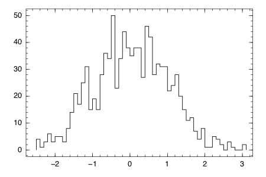

```julia
## How to plot a histogram using Winston
a = randn(1000)
ha = hist(a, 100)
plothist(ha)
```

```julia
## Let's look at a framed plot
p = FramedPlot(aspect_ratio = 1, xrange = (0, 100),
yrange = (0, 100))
n = 21
x = linspace(0, 100, n)
# Let's create a set of random variates
y1 = 40 .+ 10 * randn(n)
y2 = x .+ 5 * randn(n)

## Labels and symbol styles
a = Points(x, y1, kind = "circle")
setattr(a, label = "Points of A")
b = Points(x, y2)
setattr(b, label = "B Points")
style(b, kind = "filled circle")

## We plot a line which fits through y2
## Add a legend on the top part of the graph

s = Slope(1, (0,0), kind = "dashed")
setattr(s, label = "slope")
lg = Legend(0.1, 0.9, Any[a, b, s])
add(p, s, a, b, lg)
display(p)
```

```julia
## Use of Gadfly
using Gadfly
```

## Use of gadfly

- Large, complex, flexible
- Equivalent to ggplot2
- Grammar of Graphics (Leland Wilkinson)
- More information on gadflyjl.org
- use plot(), assign plot() to a variable, and call with display()
- Can output to svg, pdf, png, etc

```julia
## illustration
using Gadfly
dd = Gadfly.plot(x = rand(10), y = rand(10))
# draw(PNG("this.png", 12cm, 6cm), dd)
```

[figure not shown]

```julia
dd
```

```julia
## Where Gadfly can work
* Dataframes
* Functions and expressions
* Arrays and collections
```

```julia
## Let's see how gadfly works on a data frame
## we shall use the threept dataset
using DataFrames
mydata = readtable("threept.csv")
# let's get a clean data set
mydatamod = mydata[!isna(mydata[:peakhrtuseyr]), :]
# we are going to work on mydatamod
```

```julia
## here are the variables for mydatamod
names(mydatamod)
```

```julia
## Let's plot the association between incidence in 96
## and incidence in peakhrtuse percent
## for different age ranges of mammography screening

plot(mydatamod, x = "peakhrtusepct", y = "inc96",
color = "agerange")
```

```julia
## Let's plot multiline plots

x = [1:100;]
y1 = 1 - 2*rand(100)
y2 = randn(100)
```

## General motif

plot(datasource, element1, element2, mappings) datasource = dataframe, fnction, array elements = themes, scales, markers, labels, titles, guides, mappings = symbols and assignments

## Plot elements in Gadfly

- Aesthetics. -- functions, such as Stat.boxplot
- Arguments. -- Plotting arguments
- Geometry (Geom.) -- Actually does the drawing, eg Geom.line, Geom.point etc
- Guides (Guides.) -- similar to geometries

## Programming Concepts with Julia Part II

```julia
## Integers in Julia
# Find the default type
WORD_SIZE
# Find the minimum and maximum values
typemin(Int)
x = 10
x = big(x)
x^10000
## but if we did not declare big, then
y = 10
y^10000
# would return a wrong value
# +. -, * apply for integers
# / will lead to floating point
# use div and rem for integer divisor and remainder
```

```julia
## Rounding off
x = 100
y = 3
#Use of round
round(x/y, 2)
```

```julia
## working with strings
typeof("hello")
## see it understands utf
typeof("μ")
## strings are immutable
s = "Hello"
#s[2] = "Z"
## String is an array of characters, so all rules of Arrays apply
## start with 1
s[1]
## index of last character
endof(s)
## Number of characters
length(s)
## For substring, use indices
s[1:2]
s[2:end]
## String interpolation
x = 4
y = 5
# use of $ will replace the value of the var
w = "$x + $y in words, is nine"
#you can use expressions ($(x+y)) to be evaluated
w2 = "$x + $y in digits is $(x+y)"
## YOu can catenate strings
w3 = "ABC"
w4 = "DEF"
## catenate w3 and w4
## three ways
w5cat1 = *(w3, w4)
w5c2 = w3 * w4
w5c3 = string(w3, w4)
##:string is symbol, use it for ID, key,
## cannot catenate symbols
## list of methods or functions associated with Strings
# methodswith(AbstractString)
## about 400 functions
hw = "Hello World"

## search within string
search(hw, 'H')
## will return the position of the character
## Note character is given with ''
# replace
hw1 = replace(hw, "Hello", "Hi")
# Split a string on a character
hw2 = split(hw, 'H')
## if no character specified, then splits on space
hw3 = split(hw)
```

```julia
## Formatting Numbers and Strings
## @printf takes format string, variables, substitues
x = "world"
#@printf("Hello %s", x)
## it took a string and added to Hello
## the string was in the variable x
# d for integers
y = 10
#@printf("%d", y)
z = 10.2345
# f for floating point numbers with 0.x where
# x = number of decimal places
#@printf("%0.2f", z)
# this is going truncate to two decimal places
# s for srtrings
@printf("%s", x)
```

```julia
## Regular expressions
# Search for patterns in text and data
# use double quoted strings preceded by r
email = r".+@.+"
#input = "arin.basu@gmail.com"
#ismatch(email, input)
# ismatch is boolean
#=if ismatch(email, input)
    println("found")
else
    println("not found")
end =#

# An example of using shortcut with regular exp
#ismatch(email, input) ? "found" : "not found"
## ismatch is boolean
# for detailed, use "match"
input = "arin.basu#email.com"
myfind = match(email, input)
# will result in a blank
input1 = "arin.basu@email.com"
myfind2 = match(email, input1)
# will contain the entire string that matches
# offset
myfind2.offset
## starts at the position where the match begins
## offsets
myfind2.offsets
## capture part of the string
# use parentheses
emailpattern = r"(.+)@(.+)"
# we want to capture the username and hostname
input2 = "arin.basu@email.com"
m = match(emailpattern, input2)
m.captures
```

```julia
## Ranges and arrays
typeof(1:100)
```

```julia
# get a set of numbers between 1 to 9 that increases
# by units of 2
numset = collect(1:2:9)
## Ways to initialise arrays
x = 1:10 # this is a range, not array
x[1]
x1 = collect(1:10) # this is an array with
typeof(x1)
x1
## you can also initiailise with comma separation
x2 = [1,2,3,4,5]
## Specify type and number of elements
x3 = Array(Int64, 5)
## If you want to create 0 element arrays
```

```julia
## to populate the array, use push!()
x4 = Int64[]; push!(x4, 1)
push!(x4, 2)
# Create arrays from range
x5 = collect(1:6)
# indexed from 1
#x4[1]
# join array elements
join(x4, ";")
x4
```

```julia
# zero array
z1 = zeros(3)
z2 = ones(3)
```

```julia
## Some more
myarray = collect(1:100)
typeof(myarray)
sum(myarray); std(myarray)
```

## Functions in Julia

- General format function **functionname**(argument list) function logic return value end

  Or, leave the arguments empty, and functionname()
  - Value of the last expression is returned

```julia
## functions

function mult(x,y)
    x*y
end
mult(3,4) # will return 12
```

```julia
## functions return multiple values
function multi(x::Float64,y::Float64)
    x*y, x+y, x-y
end
multi(2,3)

## Arguments to functions are passed by references
# values are not copied
# they can be changed by the function

function insert_elements(anarray)
    push!(anarray, -11) # add -11 to an array
end
myarray = collect(1:5)
insert_elements(myarray)
# see this array got changed from a five element to a
# six element array
# Must define a function by the time you call it
# Indicate the argument type
# Julia is a strongly typed language.


function push_eleven(array::Array)
    push!(array, 11)

end
push_eleven(myarray)

# if we define a function without types,
# then this function becomes generic

insert_elements # should return generic function
multi

# Function defines its own scope
# you can nest one function within another
# functions with related functionality can have own file
```

```julia
## concept of optional positional arguments
f(a, b = 5) = a + b
f(1)
# optional positional arguments should always occur at the end
# optional keyword arguments
k(a; b = 5) = a * b
k(6)
k(6, b = 10)
## Anonymous functions
function myadd1(a,b)
    a + b
end

# OR
function (a, b)
    a+ b
end
## tbis above function is called anonymous function
## Use a stab character
(a,b) -> a+b
typeof(mult)
```

```julia
## first class functions
# Functions are their own type
# You can assign a function to a variable
m = mult
m(1,2)
```

```julia
# Consider this, where it becomes similar to R
addtwo = function (x) x + 2 end
```

```julia
# the above is an anonymous function, but
# you can call like
addtwo(2)
```

```julia
# counter function that returns a tuple of two
# anonymous functions
function counter()
    n = 0
    () -> n += 1, () -> n = 0
end
(addthis, clear) = counter()

## both of these are anonymous functions
```

```julia
# if we call addthis
addthis() # we get one, as n increases
```

```julia
# then we can reset this,
clear()
```

```julia
# so n here is captured by addthis and clear functions
# addthis and clear are closed over n
# hence these are called closures

## Currying functions
function add(x)
    return function f(y)
        return x + y
    end
end
add(10)(10)
## Need both parameters to run this function
# You can pass functions around
```

```julia
## Recursive functions
# You can nest one fnction wihin another
function myfn(x)
    a = x - 2
    function y(a)
        a += 1
    end
    y(a)
end

# we nested function y(a) within myfn(x)
myfn(10)
```

```julia
## REcursive conditions, ternary functions or
# short cut fnctions

# expr ? t : e
# expr = evaluate the expression
# ? if true,
# t = do true
# e = do else

sumup(n) = n > 1 ? sumup(n-1) + n : n

# what this function does is:
# 1. Test is n more than 1?
# if yes, then recursively run this function by deducting
# one from the parameter and add the n to it
# Otherwise, just mention the n and exit
# So, with 2, it will first test 2 > 1, returns true
# then sumup(1) will fail, so it will revert back to
# print 1, then add 2 to it, so the answer is 3
# thus it will recursively keep adding previous
# numbers to it
sumup(4)
```